# hw3_p2_churn

2024-02-02

## Introduction

This problem is based on one of [Kaggle’s Playground Series of competitions](https://www.kaggle.com/docs/competitions). The Playground Series is a nice way to practice building predictive models by “providing interesting and approachable datasets for our community to practice their machine learning skills”.

You do **NOT** need to download any data from Kaggle. I’ve created a smaller dataset with some other modifications for use in our HW problem. The datafile, `churn.csv`, is available in the `data` subfolder.

This particular [playground dataset involves data about bank customers](https://www.kaggle.com/competitions/playground-series-s4e1) with the target variable being a binary indicator of whether or not the customer left the bank (`Exited`), or “churned”. The playground dataset was constructed using another [Kaggle dataset on bank customer churn prediction](https://www.kaggle.com/datasets/shubhammeshram579/bank-customer-churn-prediction). Follow the preceeding link for information about the variables in this dataset.

This assignment will focus on building simple classification models for predicting bank customer churn. You’ll be doing your work right in this R Markdown document. Feel free to save it first with a modified filename that includes your name. For example, mine would be **hw3_p2_churn_isken.Rmd**.

You’ll likely need a bunch of libraries. I’ve included a few here but you should add any others that you need. If you don’t need some of these, feel free to delete such lines.

```r
library(dplyr)   # Group by analysis and other SQLish things.
library(ggplot2) # Plotting, of course
library(corrplot) # Correlation plots
library(caret)   # Many aspects of predictive modeling
library(skimr)  # An automated EDA tool
library(gt) # create table from dataframe
```

**MAJOR (10%) HACKER EXTRA** Version control

Create a new R Project for this assignment. Put the project under version control with git. Create a private GitHub repository for this project. Use git and GitHub as you go to do commits periodically and push them to your remote repository. After you have completed the assignment and pushed your last commit to your GitHub repo, add me as a Collaborator (my GitHub username is misken) so that I can see your repo.

I cover use of git and GitHub with R Studio in this module on our course web page:

- http://www.sba.oakland.edu/faculty/isken/courses/mis5470_f23/git_intro.html

This Hacker Extra is worth 10% of the total number of points in the assignment.

## Step 1: Read in data

Read the `churn.csv` file from the `data` subfolder into a dataframe named `churn`.

```r
churn <- read.csv("./data/churn.csv")
str(churn)
```

```
## 'data.frame':    33007 obs. of  11 variables:
##  $ CreditScore    : int  678 678 583 645 773 746 607 686 699 668 ...
##  $ Geography      : chr  "France" "Spain" "Germany" "Germany" ...
##  $ Gender         : chr  "Male" "Male" "Male" "Female" ...
##  $ Age            : num  40 37 40 55 35 33 26 45 31 38 ...
##  $ Tenure         : int  10 1 4 8 9 7 1 4 7 4 ...
##  $ Balance        : num  0 138476 81274 120105 0 ...
##  $ NumOfProducts  : int  2 1 1 1 2 2 2 1 2 2 ...
##  $ HasCrCard      : int  1 1 1 1 0 1 1 1 1 1 ...
##  $ IsActiveMember : int  0 0 1 0 1 1 0 0 0 1 ...
##  $ EstimatedSalary: num  184867 106852 170843 125083 87549 ...
##  $ Exited         : int  0 0 0 1 0 0 0 1 0 0 ...
```

```r
summary(churn)
```

```
##   CreditScore     Geography            Gender               Age
##  Min.   :350.0   Length:33007       Length:33007       Min.   :18.00
##  1st Qu.:598.0   Class :character   Class :character   1st Qu.:32.00
##  Median :659.0   Mode  :character   Mode  :character   Median :37.00
##  Mean   :656.4                                         Mean   :38.17
##  3rd Qu.:710.0                                         3rd Qu.:42.00
##  Max.   :850.0                                         Max.   :92.00
##      Tenure          Balance       NumOfProducts     HasCrCard
##  Min.   : 0.000   Min.   :     0   Min.   :1.000   Min.   :0.0000
##  1st Qu.: 3.000   1st Qu.:     0   1st Qu.:1.000   1st Qu.:1.0000
##  Median : 5.000   Median :     0   Median :2.000   Median :1.0000
##  Mean   : 5.034   Mean   : 54785   Mean   :1.555   Mean   :0.7521
##  3rd Qu.: 7.000   3rd Qu.:118992   3rd Qu.:2.000   3rd Qu.:1.0000
##  Max.   :10.000   Max.   :212693   Max.   :4.000   Max.   :1.0000
##  IsActiveMember   EstimatedSalary         Exited
##  Min.   :0.0000   Min.   :    11.58   Min.   :0.0000
##  1st Qu.:0.0000   1st Qu.: 74637.76   1st Qu.:0.0000
##  Median :0.0000   Median :118522.73   Median :0.0000
##  Mean   :0.4977   Mean   :112716.47   Mean   :0.2093
##  3rd Qu.:1.0000   3rd Qu.:155523.48   3rd Qu.:0.0000
##  Max.   :1.0000   Max.   :199992.48   Max.   :1.0000
```

```r
skim(churn)
```

Data summary

| Name | churn |
| --- | --- |
| Number of rows | 33007 |
| Number of columns | 11 |
| _______________________ |  |
| Column type frequency: |  |
| character | 2 |
| numeric | 9 |
| ________________________ |  |
| Group variables | None |

**Variable type: character**

| skim_variable | n_missing | complete_rate | min | max | empty | n_unique | whitespace |
| --- | --- | --- | --- | --- | --- | --- | --- |
| Geography | 0 | 1 | 5 | 7 | 0 | 3 | 0 |
| Gender | 0 | 1 | 4 | 6 | 0 | 2 | 0 |

**Variable type: numeric**

| skim_variable | n_missing | complete_rate | mean | sd | p0 | p25 | p50 | p75 | p100 | hist |
| --- | --- | --- | --- | --- | --- | --- | --- | --- | --- | --- |
| CreditScore | 0 | 1 | 656.44 | 80.20 | 350.00 | 598.00 | 659.0 | 710.0 | 850.0 | ▁▂▇▇▂ |
| Age | 0 | 1 | 38.17 | 8.87 | 18.00 | 32.00 | 37.0 | 42.0 | 92.0 | ▃▇▂▁▁ |
| Tenure | 0 | 1 | 5.03 | 2.80 | 0.00 | 3.00 | 5.0 | 7.0 | 10.0 | ▇▇▇▇▅ |
| Balance | 0 | 1 | 54785.43 | 62611.67 | 0.00 | 0.00 | 0.0 | 118991.8 | 212693.0 | ▇▁▃▂▁ |
| NumOfProducts | 0 | 1 | 1.56 | 0.54 | 1.00 | 1.00 | 2.0 | 2.0 | 4.0 | ▇▇▁▁▁ |
| HasCrCard | 0 | 1 | 0.75 | 0.43 | 0.00 | 1.00 | 1.0 | 1.0 | 1.0 | ▂▁▁▁▇ |
| IsActiveMember | 0 | 1 | 0.50 | 0.50 | 0.00 | 0.00 | 0.0 | 1.0 | 1.0 | ▇▁▁▁▇ |
| EstimatedSalary | 0 | 1 | 112716.47 | 50260.92 | 11.58 | 74637.76 | 118522.7 | 155523.5 | 199992.5 | ▂▆▇▇▇ |
| Exited | 0 | 1 | 0.21 | 0.41 | 0.00 | 0.00 | 0.0 | 0.0 | 1.0 | ▇▁▁▁▂ |

Use `str`, `summary`, and `skim` to get a sense of the data. The binary target variable is `Exited` where 1 indicates that the customer left the bank (they “churned”). You’ll notice that some of the fields are numeric and some are character data. You might also notice that there are fewer variables in our churn dataset than in the original Kaggle versions.

## Step 2: Factor conversions

Some of the variables clearly should be factors. Change all of the variables to factors that you think should be. Include an explanation of why each of these variables should be converted to factors.

```r
churn[,c(2,3,8,9,11)] <- lapply(churn[,c(2,3,8,9,11)], factor)
str(churn)
```

```
## 'data.frame':    33007 obs. of  11 variables:
##  $ CreditScore    : int  678 678 583 645 773 746 607 686 699 668 ...
##  $ Geography      : Factor w/ 3 levels "France","Germany",..: 1 3 2 2 3 1 1 1 1 2 ...
##  $ Gender         : Factor w/ 2 levels "Female","Male": 2 2 2 1 2 2 2 1 2 2 ...
##  $ Age            : num  40 37 40 55 35 33 26 45 31 38 ...
##  $ Tenure         : int  10 1 4 8 9 7 1 4 7 4 ...
##  $ Balance        : num  0 138476 81274 120105 0 ...
##  $ NumOfProducts  : int  2 1 1 1 2 2 2 1 2 2 ...
##  $ HasCrCard      : Factor w/ 2 levels "0","1": 2 2 2 2 1 2 2 2 2 2 ...
##  $ IsActiveMember : Factor w/ 2 levels "0","1": 1 1 2 1 2 2 1 1 1 2 ...
##  $ EstimatedSalary: num  184867 106852 170843 125083 87549 ...
##  $ Exited         : Factor w/ 2 levels "0","1": 1 1 1 2 1 1 1 2 1 1 ...
```

> Because `Gender`, `HasCrCard`, `IsAtiveMember` , and `Exited` represents categorical variables with two levels ( Male and Female, 1 and 0) converting it to a factor would be appropriate.

> Converting `Geography` column to a factor is also appropriate since it represents categorical data with three distinct countries. It would be easier to perform analysis.

## Step 3 - Partition into training and test sets

We will use the [caret](https://topepo.github.io/caret/) package to do the partitioning of our data into training and test dataframes. Just run this chunk to create training and test datasets. This way we’ll all be working with the same datasets. Notice that the test set is 20% of the full dataset.

```r
# Simple partition into train (80%) and test (20%) set
set.seed(687) # Do NOT change this
trainIndex <- createDataPartition(churn$Exited, p = .8,
                                  list = FALSE,
                                  times = 1)

churn_train <- churn[as.vector(trainIndex), ]
churn_test <- churn[-as.vector(trainIndex), ]
```

Find the number of customers and the percentage of customers for the two `Exited` levels. You’ll see that there are about 20% of the bank customers exited.

```r
number_exited <- table(churn$Exited)
number_exited
```

```
##
##     0     1
## 26099  6908
```

```r
prop.table(number_exited)*100
```

```
##
##        0        1
## 79.07111 20.92889
```

## Step 4: EDA

Do some EDA to try to uncover some relationships that may end up being useful in building a predictive model for `Exited`. You learned things in HW2 which should be useful here. You should **ONLY** use `churn_train` for your EDA. You should explore all of the variables.

### Basic statistics

To see an overview of the distribution of numerical variables, we calculate the summary statistics.

```r
summary(churn_train)
```

```
##   CreditScore      Geography        Gender           Age
##  Min.   :350.0   France :15223   Female:11527   Min.   :18.00
##  1st Qu.:597.0   Germany: 5421   Male  :14880   1st Qu.:32.00
##  Median :659.0   Spain  : 5763                  Median :37.00
##  Mean   :656.2                                  Mean   :38.18
##  3rd Qu.:711.0                                  3rd Qu.:42.00
##  Max.   :850.0                                  Max.   :92.00
##      Tenure          Balance       NumOfProducts   HasCrCard IsActiveMember
##  Min.   : 0.000   Min.   :     0   Min.   :1.000   0: 6569   0:13268
##  1st Qu.: 3.000   1st Qu.:     0   1st Qu.:1.000   1:19838   1:13139
##  Median : 5.000   Median :     0   Median :2.000
##  Mean   : 5.028   Mean   : 54629   Mean   :1.556
##  3rd Qu.: 7.000   3rd Qu.:118892   3rd Qu.:2.000
##  Max.   :10.000   Max.   :212693   Max.   :4.000
##  EstimatedSalary     Exited
##  Min.   :    11.58   0:20880
##  1st Qu.: 74800.99   1: 5527
##  Median :117832.88
##  Mean   :112685.17
##  3rd Qu.:154845.56
##  Max.   :199992.48
```

### Histograms and boxplots

We create histogram for the variables `CreditScore`,`Age`, `Balance`, `EstimatedSalary` by `Exited` status.

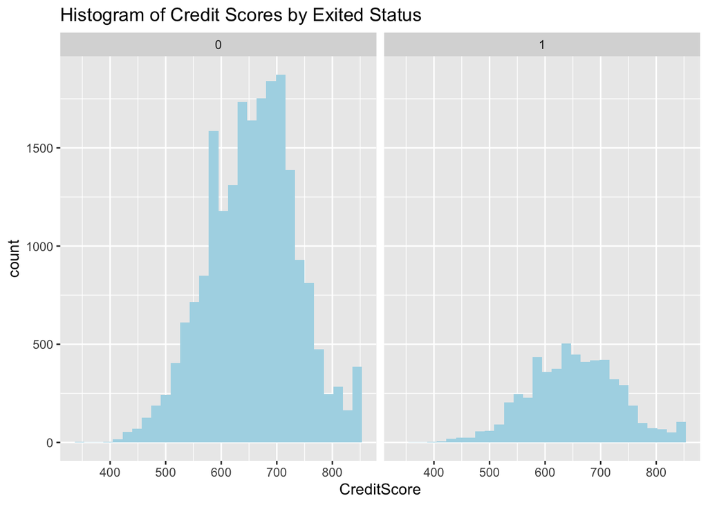

```r
# CreditScore by Exited
ggplot(churn_train, aes(x=CreditScore)) +
  geom_histogram(bins=30,fill="lightblue") +
  facet_wrap(~Exited) +
  ggtitle("Histogram of Credit Scores by Exited Status")
```

> The distribution of credit scores for customers who have churned (1) and have not churned (0) are approcimately normal with the peak around 650 - 700. It appears that the counts of customers who churned is lower than that of the non-churned customers. However, there is no major difference in credit score distribution between the two groups.

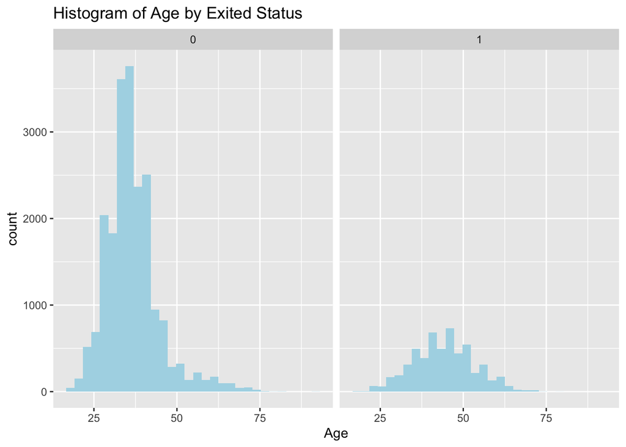

```r
# Age by Exited
ggplot(churn_train, aes(x=Age)) +
  geom_histogram(bins=30,fill="lightblue") +
  facet_wrap(~Exited) +
  ggtitle("Histogram of Age by Exited Status")
```

> The distribution of ages for customers who have not churned (0) shows a higher frequency of younger customers, with a peak in the histogram around the age of 30-40 years. The distribution tapers off as age increases. On contrary, The distribution of ages for customers who have churned (1) is in the older range - the peak is around the age of 40-50 years old suggesting that middle-aged customers are more likely to churn compared to younger or older customer.

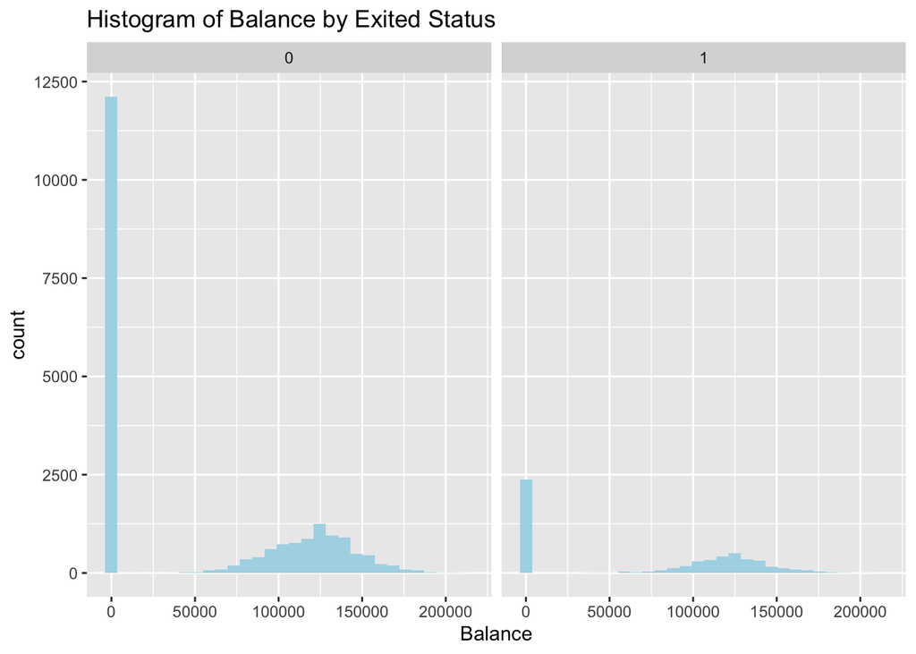

```r
# Balance by Exited
ggplot(churn_train, aes(x=Balance)) +
  geom_histogram(bins=30,fill="lightblue") +
  facet_wrap(~Exited) +
  ggtitle("Histogram of Balance by Exited Status")
```

> It looks like we have two sub-balanced categories in each group. There’s a huge spike at 0 balance for non - exited customers, indicating a significant number of customers with a zero or very low balance. Aside from the spike, the distribition [in much lower frequency comapre to the spike] appears to be roughly normal with a slight peak around the balance of $125,000. For the churned plot, the 0 balanced - spike is not as large as in the non-churned. Beyond the “spike”, the distribution is roughly normal with the peak balanced around $125,000 also.

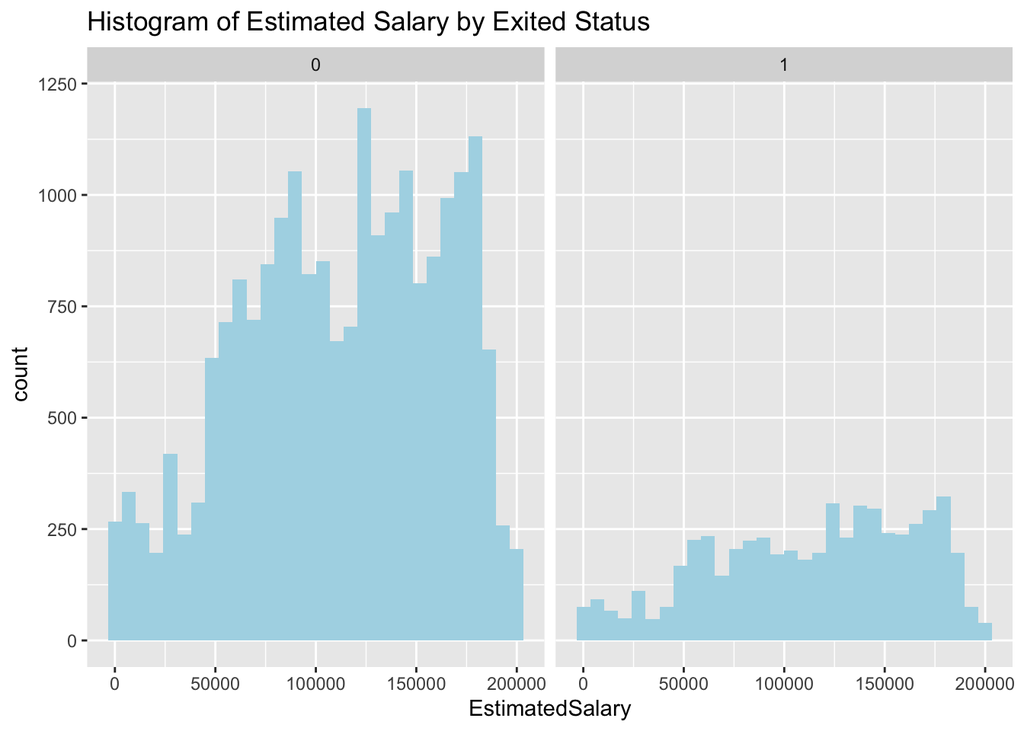

```r
# EstimatedSalary by Exited
ggplot(churn_train, aes(x=EstimatedSalary)) +
  geom_histogram(bins=30,fill="lightblue") +
  facet_wrap(~Exited) +
  ggtitle("Histogram of Estimated Salary by Exited Status")
```

> Distributions of estimated salaries for both groups are similar. Although the frequency of non-churned are much higher than churned customers.

We use Boxplotnto identify potential outliers

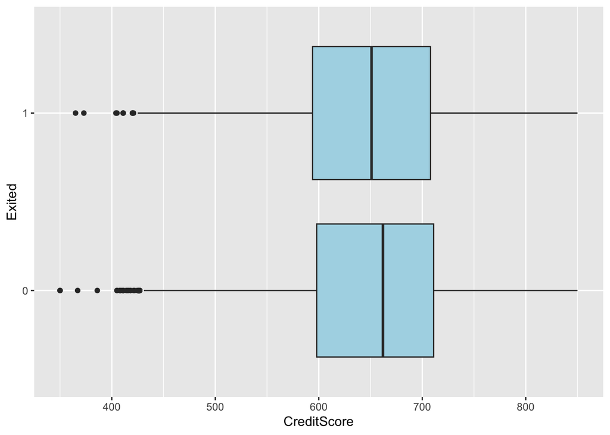

```r
ggplot(churn_train,aes(x=CreditScore, y=Exited)) +
  geom_boxplot(fill="lightblue")
```

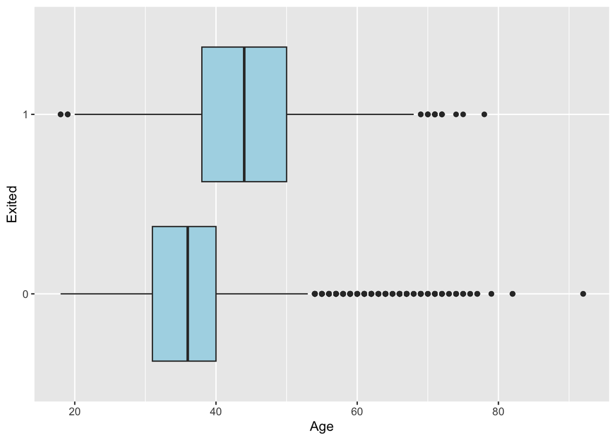

```r
ggplot(churn_train,aes(x=Age, y=Exited)) +
  geom_boxplot(fill="lightblue")
```

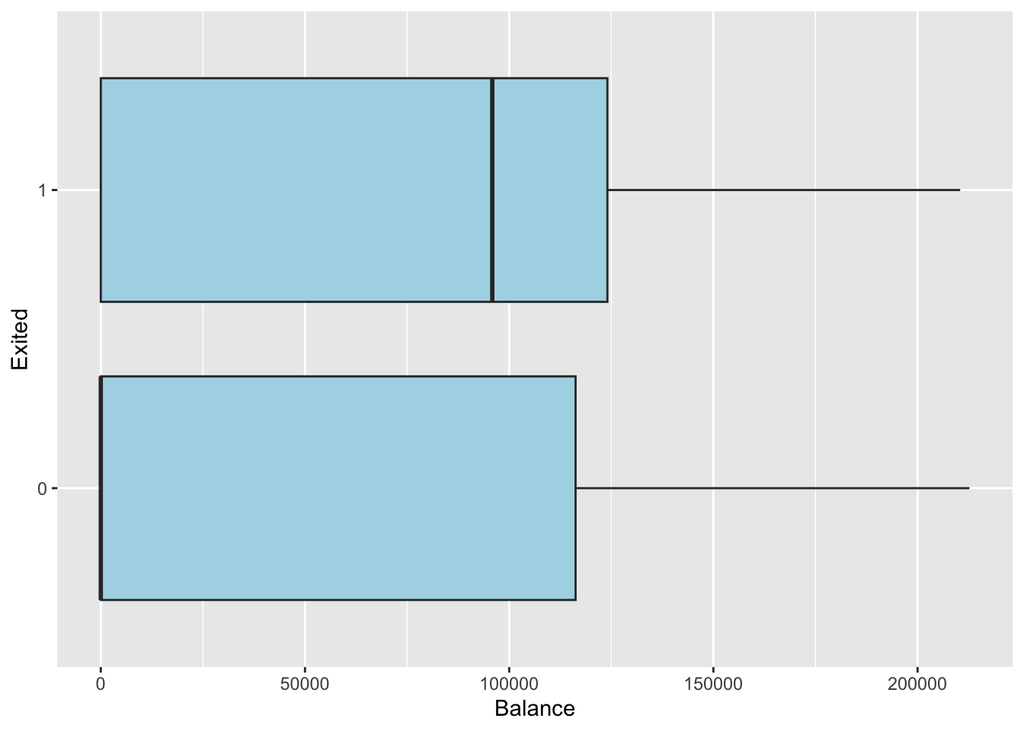

```r
ggplot(churn_train,aes(x=Balance, y=Exited)) +
  geom_boxplot(fill="lightblue")
```

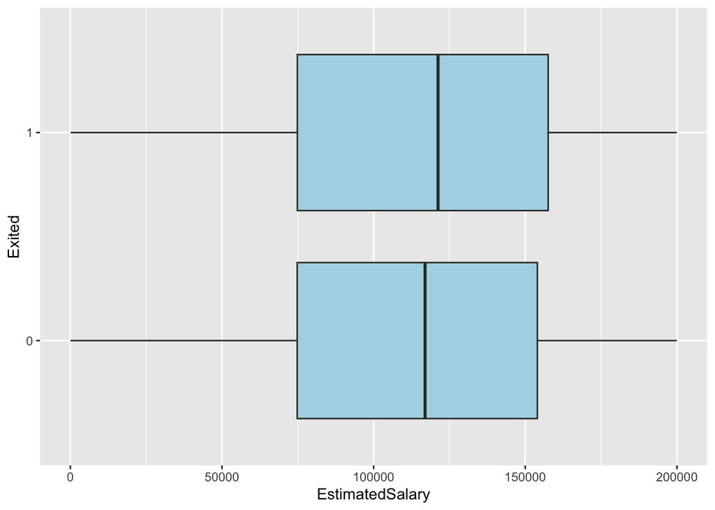

```r
ggplot(churn_train,aes(x=EstimatedSalary, y=Exited)) +
  geom_boxplot(fill="lightblue")
```

> There are outliers for `CreditScore` and `Age`

We create barplots to visualize the distribution of categorical variables like `Geography`, `Gender`, `HasCrCard`, `IsActiveMember`

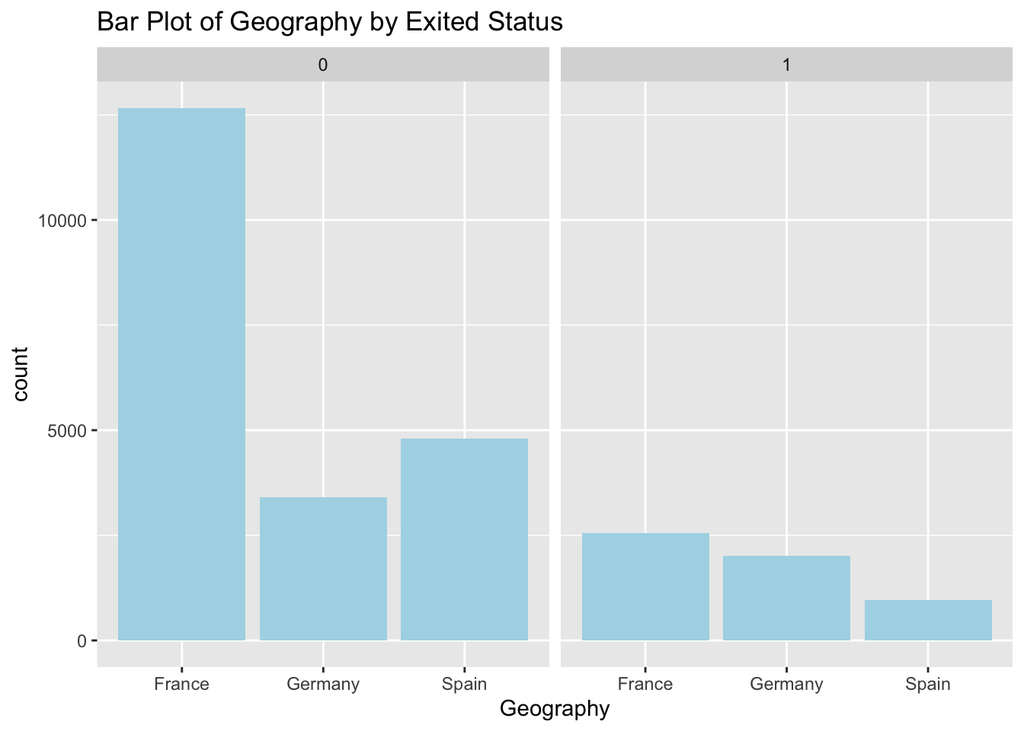

```r
ggplot(churn_train) +
  geom_bar(aes(x=Geography), fill="lightblue") +
  facet_wrap(~Exited) +
  labs(title = "Bar Plot of Geography by Exited Status")
```

> Comparing the two groups, non-exited customers have higher in number than churn customer. France has the highest number of non-exited customers compared to Germany and Spain. Germany has the lowest number of non-exited customers among the three regions.

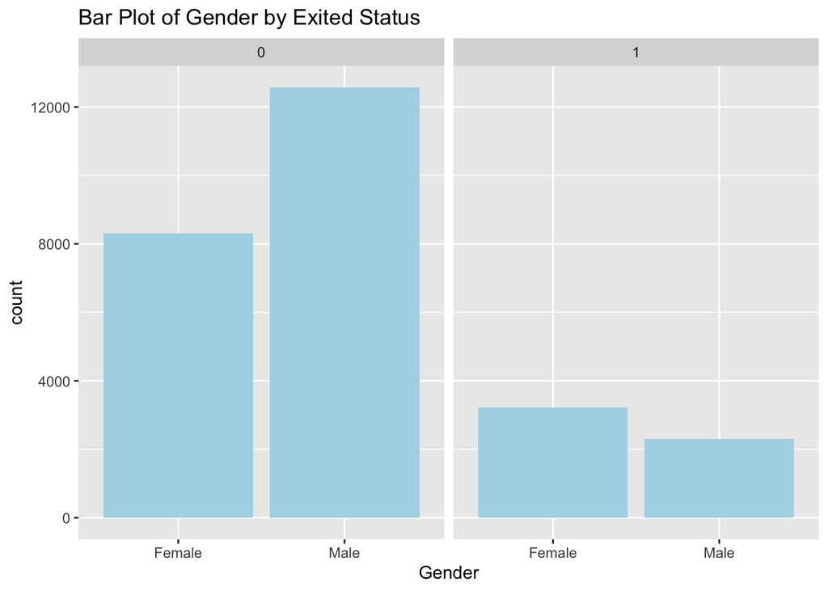

```r
ggplot(churn_train) +
  geom_bar(aes(x=Gender), fill="lightblue") +
  facet_wrap(~Exited) +
  labs(title = "Bar Plot of Gender by Exited Status")
```

> For the panel who have not exited, the bar for males is taller than the bar for females, indicating that there are more male customers who have not exited compared to female customers, which demonstrate thr fact that here are more female customers who have exited compared to male customers. in the right panel.

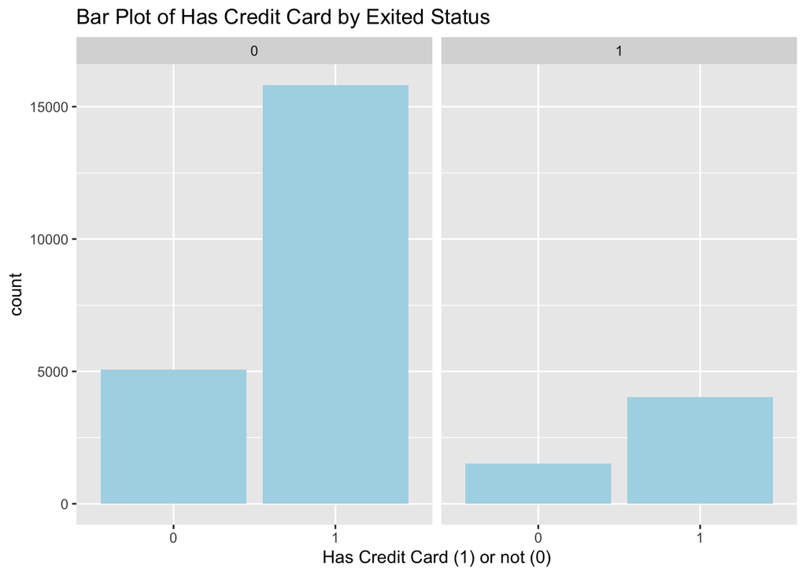

```r
ggplot(churn_train) +
  geom_bar(aes(x=HasCrCard), fill="lightblue") +
  facet_wrap(~Exited) +
  labs(title = "Bar Plot of Has Credit Card by Exited Status", x="Has Credit Card (1) or not (0)")
```

> The majority of non-exited customers possess a credit card as it is the same for exited customers. However, the difference is less prominent compared to the non-exited customers.

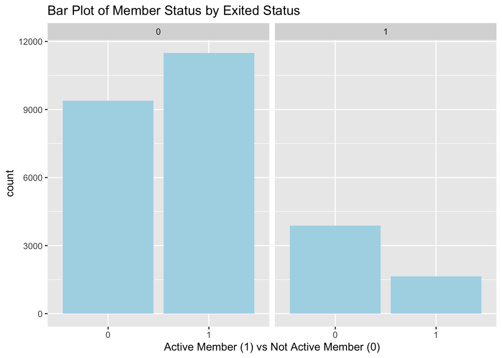

```r
ggplot(churn_train) +
  geom_bar(aes(x=IsActiveMember), fill="lightblue") +
  facet_wrap(~Exited) +
  labs(title = "Bar Plot of Member Status by Exited Status", x="Active Member (1) vs Not Active Member (0)")
```

> There are more active members who have not exited compared to not active members.

### Corrlation Among Predictors

Calculate a correlation matrix to understand the relationships between them.

```r
# correlation matrix
corr_matrix <- cor(churn_train[,c(1,4,6,10)])
corr_matrix
```

```
##                  CreditScore          Age    Balance EstimatedSalary
## CreditScore      1.000000000 -0.002091792 0.00282448    -0.008239656
## Age             -0.002091792  1.000000000 0.05819124    -0.013332427
## Balance          0.002824480  0.058191240 1.00000000     0.008985150
## EstimatedSalary -0.008239656 -0.013332427 0.00898515     1.000000000
```

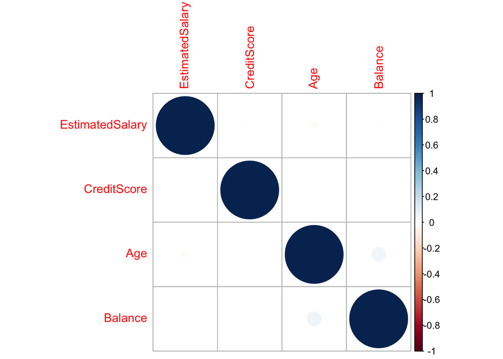

```r
# correlation plot
corrplot(corr_matrix, order = "hclust")
```

> There are very little correlations between the varibles.

## Step 5 - Building and evaluation of predictive classification models

Now that you know a little more about the data, it’s time to start building a few classification models for `Exited`. We will start out using overall prediction accuracy as our metric but we might want to consider other metrics.

**QUESTION** Why might overall prediction accuracy not be the most appropriate metric to consider? What other metrics might be important and why?

> Since we have imbalanced data (about 20% of the bank customers exited, the other ~80% is not), overall prediction accuracy not be the most appropriate metric to consider. This could result in bias accuracy. For instance, majority baseline classifier which always assigns the non-exited would reach ~80% accuracy since it would correctly predict ~80% non-exited.

> Other metrics we might consider are: confusion matrix and ROC. These methods are appropriate for binary response varibles. Confusion matrix provides tables output to see the number of correct and incorrect predictions for each class (true positives, true negatives, false positives, and false negatives). From there, we can calculate metrics such as accuracy (accuracy $=\dfrac{TP+TN}{TP+TN+FP+FN}$). ROC visualizes the trade off between classes. [this part is straight out of the book]For example, we can achieve high recall (True Positive) at the expense of a high False Positive by selecting a threshold that move us to the top right of the graph.